# MetaCell based analyses - Tumor compartment

Kaspar Bresser 20/10/2021

- Import data
- Plot marker genes
- GSEA MC12
- Violin plots

Used the analysis below to investigate genes of interest in Tumor MetaCell 12, which was specifically enriched in QPCTL deficient TMEs

## Import data

Get the metacell object

```r
scdb_init(here("Data", "Metacell_files_tumor"))
mc <- scdb_mc("QPCTL_Tum_MC2")
```

## Plot marker genes

Check the top and bottom 5 genes of MC12.

```r
lfp <- as.data.frame(log2(mc@mc_fp))

lfp %>%
  rownames_to_column("genes") %>%
  dplyr::select("genes", "12") %>%
  filter(dense_rank(`12`) <= 5 | dense_rank(-`12`) <= 5) -> TopBot.MC12

TopBot.MC12
```

```
##     genes         12
## 1     B2m  2.0402133
## 2    Gbp7  1.6783662
## 3   Bnip3 -0.4924163
## 4  Ifitm3  2.1572273
## 5    Bst2  1.8541797
## 6   Ero1l -0.4452218
## 7    Ugp2 -0.4680698
## 8     Fos -0.5096215
## 9   Iigp1  1.9753261
## 10 Malat1 -0.5892173
```

and plot as waterfall.

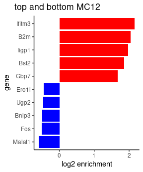

```r
TopBot.MC12 %>%
  mutate(genes = reorder(genes, `12`)) %>%
  ggplot(aes(x = genes, y = `12`, fill = `12` > 0))+
    geom_bar(stat = "identity")+
    scale_fill_manual(values=c("blue", "red"))+
    labs(title = "top and bottom MC12", x = "gene", y = "log2 enrichment")+
    theme(legend.position = "none", plot.title = element_text(hjust = -1))+
    coord_flip()
```

```r
ggsave(here("Figs", "tumor", "MC12_top_bottom.pdf"), width = 1, height = 2, scale = 2.5)
```

## GSEA MC12

First get the top and bottom 200 genes of MC12. Will use as input for fgsea analysis.

```r
lfp %>%
  rownames_to_column("genes") %>%
  dplyr::select("genes", "12") %>%
  deframe() %>%
  sort(decreasing = T) -> stats

# subset to 200 highest and 200 lowest values
stats <- stats[dense_rank(stats) <= 200 | dense_rank(-stats) <= 200]

str(stats)
```

```
##  Named num [1:400] 2.16 2.04 1.98 1.85 1.68 ...
##  - attr(*, "names")= chr [1:400] "Ifitm3" "B2m" "Iigp1" "Bst2" ...
```

Now import the pathways

```r
pathways.hallmark <- as.data.frame(msigdbr(species = "Mus musculus", category = "H"))
pathways <- split(pathways.hallmark$gene_symbol, pathways.hallmark$gs_name)

pathways %>%
  head(10) %>%
  str()
```

```
## List of 10
##  $ HALLMARK_ADIPOGENESIS           : chr [1:200] "Abca1" "Abcb8" "Acaa2" "Acadl" ...
##  $ HALLMARK_ALLOGRAFT_REJECTION    : chr [1:207] "Aars" "Abce1" "Abi1" "Ache" ...
##  $ HALLMARK_ANDROGEN_RESPONSE      : chr [1:125] "Abcc4" "Abhd2" "Acsl3" "Actn1" ...
##  $ HALLMARK_ANGIOGENESIS           : chr [1:36] "Apoh" "App" "Ccnd2" "Col3a1" ...
##  $ HALLMARK_APICAL_JUNCTION        : chr [1:199] "Acta1" "Actb" "Actc1" "Actg1" ...
##  $ HALLMARK_APICAL_SURFACE         : chr [1:44] "Adam10" "Adipor2" "Afap1l2" "Akap7" ...
##  $ HALLMARK_APOPTOSIS              : chr [1:161] "Add1" "Aifm3" "Ank" "Anxa1" ...
##  $ HALLMARK_BILE_ACID_METABOLISM   : chr [1:115] "Abca1" "Abca2" "Abca3" "Abca4" ...
##  $ HALLMARK_CHOLESTEROL_HOMEOSTASIS: chr [1:75] "Abca2" "Acat3" "Acss2" "Actg1" ...
##  $ HALLMARK_COAGULATION            : chr [1:139] "A2m" "Acox2" "Adam9" "Ang" ...
```

And perform the analysis.

```r
fgseaRes <- fgsea(pathways=pathways, stats=stats, minSize = 10)
```

Now we can plot the enrichment of the pathways foudn by fgsea.

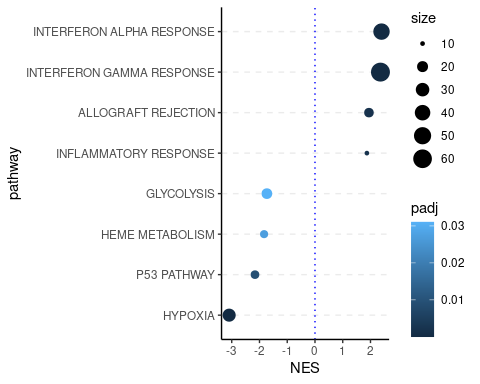

```r
fgseaRes %>%
  filter(pval < 0.05)  %>%
  mutate(pathway = gsub("HALLMARK_", "", pathway),
         pathway = gsub("_", " ", pathway),
         pathway = reorder(pathway, NES)) %>%
  ggplot( aes(x = NES, y = pathway))+
    geom_point(aes(size = size, color  = padj))+
    grids(axis = "y", linetype = "dashed")+
    geom_vline(xintercept = 0, color = "blue", linetype = "dotted")
```

```r
ggsave(filename = here("Figs", "tumor", "MC12_Pathways_Hallmark.pdf"), device = "pdf", width = 5, height = 4, useDingbats=FALSE )

fgseaRes %>%
  filter(pval < 0.05)  %>%
  write_tsv(here("Output", "tumor_MC12_GSEA_Hallmark.tsv"))
```

And plot the top scoring pathways.

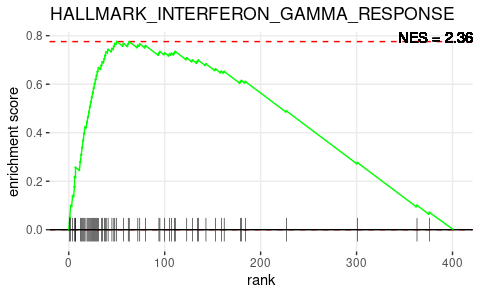

```r
pw <- "HALLMARK_INTERFERON_GAMMA_RESPONSE"

fgseaRes %>%
  dplyr::filter(pathway == pw) %>%
  pull(NES) %>% round(digits = 2) -> nes

plotEnrichment(pathway = pathways[[pw]], stats)+
  ggtitle(pw)+
  geom_text(aes(label = paste0(c("NES = ", as.character(nes)), collapse = ""), x = Inf, y = Inf  ),
            vjust = "inward", hjust = "inward")
```

```r
ggsave(filename = here("Figs", "tumor", "MC12_Pathway_IFNy.pdf"), device = "pdf", width = 5, height = 3, useDingbats=FALSE )
```

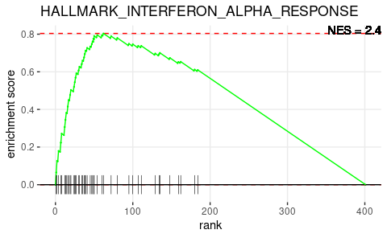

```r
pw <- "HALLMARK_INTERFERON_ALPHA_RESPONSE"

fgseaRes %>%
  dplyr::filter(pathway == pw) %>%
  pull(NES) %>% round(digits = 2) -> nes

plotEnrichment(pathway = pathways[[pw]], stats)+
  ggtitle(pw)+
  geom_text(aes(label = paste0(c("NES = ", as.character(nes)), collapse = ""), x = Inf, y = Inf  ),
            vjust = "inward", hjust = "inward")
```

```r
ggsave(filename = here("Figs", "tumor", "MC12_Pathway_IFNa.pdf"), device = "pdf", width = 5, height = 3, useDingbats=FALSE )
```

## Violin plots

Next, we’ll check how various IFN responsive genes are expressed across the different MCs.

Import the seurat object.

```r
seurat.object <- read_rds(here("Data", "seurat_Tum.rds"))
```

Normalize and scale the data.

```r
seurat.object <- NormalizeData(seurat.object, assay = "RNA", normalization.method = "CLR")
seurat.object <- ScaleData(seurat.object, assay = "RNA")
```

Extract the expression data for all genes in the IFNg geneset.

```r
IFN.genes <- pathways[["HALLMARK_INTERFERON_GAMMA_RESPONSE"]]

seurat.object %>%
  GetAssayData( slot = "scale.data", assay = "RNA")%>%
  as.matrix() %>%
  t() %>%
  as.data.frame() %>%
  as_tibble(rownames = "cellcode") %>%
  dplyr::select(one_of(c("cellcode", IFN.genes))) -> IFN.gene.expression
IFN.gene.expression
```

```
## # A tibble: 10,153 × 206
##    cellcode     Adar   Apol6 Arid5b  Arl4a   Auts2     B2m   Bank1  Batf2   Bpgm
##    <chr>       <dbl>   <dbl>  <dbl>  <dbl>   <dbl>   <dbl>   <dbl>  <dbl>  <dbl>
##  1 AAACCCAAG… -0.493 -0.0887 -0.729 -0.527 -0.0516  0.0164 -0.0199 -0.172  2.11
##  2 AAACCCAAG… -0.493 -0.0887  0.716 -0.527 -0.0516 -0.860  -0.0199 -0.172 -0.643
##  3 AAACCCAAG… -0.493 -0.0887 -0.729  2.79  -0.0516 -0.234  -0.0199 -0.172 -0.643
##  4 AAACCCAAG… -0.493 -0.0887  0.716 -0.527 -0.0516  0.238  -0.0199 -0.172  2.11
##  5 AAACCCAAG… -0.493 -0.0887 -0.729 -0.527 -0.0516 -0.522  -0.0199 -0.172  2.11
##  6 AAACCCACA… -0.493 -0.0887  0.716 -0.527 -0.0516 -0.860  -0.0199 -0.172 -0.643
##  7 AAACCCACA… -0.493 -0.0887 -0.729  1.53  -0.0516  1.33   -0.0199 -0.172 -0.643
##  8 AAACCCACA…  1.69  -0.0887 -0.729 -0.527 -0.0516 -0.234  -0.0199 -0.172 -0.643
##  9 AAACCCAGT… -0.493 -0.0887  0.716  2.79  -0.0516 -0.234  -0.0199 -0.172 -0.643
## 10 AAACCCAGT…  1.69  -0.0887 -0.729 -0.527 -0.0516  0.238  -0.0199 -0.172 -0.643
## # … with 10,143 more rows, and 196 more variables: Bst2 <dbl>, Btg1 <dbl>,
## #   C1rb <dbl>, C1s2 <dbl>, Casp1 <dbl>, Casp3 <dbl>, Casp4 <dbl>, Casp7 <dbl>,
## #   Casp8 <dbl>, Ccl2 <dbl>, Ccl5 <dbl>, Ccl7 <dbl>, Cd274 <dbl>, Cd38 <dbl>,
## #   Cd40 <dbl>, Cd69 <dbl>, Cd74 <dbl>, Cd86 <dbl>, Cdkn1a <dbl>, Cfb <dbl>,
## #   Cfh <dbl>, Ciita <dbl>, Cmklr1 <dbl>, Cmpk2 <dbl>, Cmtr1 <dbl>,
## #   Csf2rb2 <dbl>, Cxcl10 <dbl>, Cxcl9 <dbl>, Ddx58 <dbl>, Ddx60 <dbl>,
## #   Dhx58 <dbl>, Eif2ak2 <dbl>, Eif4e3 <dbl>, Epsti1 <dbl>, Fas <dbl>, …
```

I’ve selected a number of genes of interest, picked out of the leading edge of the GSEA.

```r
select.genes <- c("Ifitm3", "B2m", "Bst2", "Stat1", "Cxcl10", "Psmb9", "Psmb8", "Psmb10", "Psme1",
              "Isg15", "Psme2", "Tap1", "Rnf213", "Zbp1", "Rsad2", "Ifit3", "Lgals3bp", "Tapbp", "Xaf1",
              "Gbp3", "Irf1", "Ifi35", "Herc6", "Parp12", "Nmi", "Parp14", "Rtp4", "Lap3", "Eif2ak2", "Cd74",
              "Samd9l", "Ddx58", "Ogfr", "Psma2")
```

prep for plotting.

```r
IFN.gene.expression %>%
  pivot_longer(!cellcode, names_to = "gene", values_to =  "umi") %>%
  left_join(enframe(mc@mc, "cellcode", "MC")) %>%
  na.omit() %>%
  mutate(MC = as.factor(MC)) %>%
  filter(gene %in% select.genes) -> violin.data

violin.data
```

```
## # A tibble: 170,442 × 4
##    cellcode           gene       umi MC
##    <chr>              <chr>    <dbl> <fct>
##  1 AAACCCACAATCAAGA-1 B2m     -0.860 2
##  2 AAACCCACAATCAAGA-1 Bst2    -0.929 2
##  3 AAACCCACAATCAAGA-1 Cd74    -0.297 2
##  4 AAACCCACAATCAAGA-1 Cxcl10  -0.427 2
##  5 AAACCCACAATCAAGA-1 Ddx58    1.73  2
##  6 AAACCCACAATCAAGA-1 Eif2ak2 -0.691 2
##  7 AAACCCACAATCAAGA-1 Gbp3    -0.275 2
##  8 AAACCCACAATCAAGA-1 Herc6   -0.581 2
##  9 AAACCCACAATCAAGA-1 Ifi35   -0.494 2
## 10 AAACCCACAATCAAGA-1 Ifit3   -0.249 2
## # … with 170,432 more rows
```

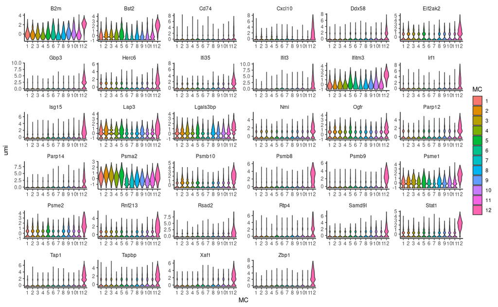

```r
violin.data %>%
  ggplot(aes(x = MC, y = umi, fill = MC))+
    geom_violin(scale = "width")+
    facet_wrap(~gene, scales = "free")+
    theme( strip.background = element_blank())
```

```r
ggsave(here("Figs", "tumor", "MC_IFN_Violins.pdf"), width = 12, height = 6, scale = 1.2)
```